### Rhagoletis project on circadian rhythms

Authors: Dan Hahn and Andrew Nguyen

Start date: 2017-08-14 End date/last edited:

## Table of Contents:

- Repository Layout
- Project Workflow
- Meta data for critical datasets

### Repository Layout

- **Data/**:
- 2017-08-24_rhagoletis_data_sheet.xlsx : master datasheet where we collated data; metadata below
- 2017-08-24_rhagoletis_data_sheet_2017-12-13_dataslice.csv; a snapshot of the data on 2017-12-13
- 2017-10-12_trik_cohort_list_free_run.xlsx : table indicating when each cohort needs to be put into free run experiment (day 8)
- 2017-10-16_Trikinetics_cohorts_eclosion.csv : csv of trikinetics cohorts
- 2017-10-22_skipped_apple_cohort_eclosions.xlsx : data collected of skipped cohorts
- 2017-11-17_subset_host_comparison_trik_data_extract.csv
- 2017-12-03_summary_table_finding_periods.xlsx
- 2017-12-05-overwintering_table_of_months.xlsx
- 2018-01-08__overwintering_exit_timing_5months.xlsx
- **randomizing/**: Folder used to save cohorts into separate files to randomize and includes the randomized outputs with uniqueIDs
- **raw/**:
  - **Respirometry/**: expedata and csv files
  - **Trikinetics/**: trikinetics monitor data sets; raw
- Sampling_mass_purgetimes.xlsx : datacollection sheet that we print out and fill in to put into our physical notebook
- **Documents/**:
- Detailed Experimental workflow.md : markdown file using mermaid to draw a workflow
- Detailed Experimental workflow.png : png version
- Methods.md
- Rhagoletis_handling_processing.md : protocols for handling *Rhagoletis*
- Rhagoletis_handling_processing.pdf : pdf version
- Workflow_for_trikinetics_data_transformation.md : markdown file of the workflow for trikinetics data
- Workflow_for_trikinetics_data_transformation.pdf : pdf version
- **Results/**: Preliminary figures right now
- **Scripts_analyses/**:
- 2017-09-04_randomization.Rmd
- 2017-09-27_prelim_circadian_rhythm_trikinetics.Rmd
- 2017-10-16_prelim_free_run.Rmd
- 2017-11-16_processing_master_data.html
- 2017-11-16_processing_master_data.Rmd
- 2017-11-19_prelim_data_subset_extract_behaviors.Rmd
- 2017-12-08_15min_bins_subset_behavior.csv
- 2017-12-08_allm_all_monitorscombined.csv
- 2017-12-08_subset_inds_15min_bins_vsdays.png
- Scripts_analyses.Rproj
- Readme.md : …this file…
- Research_Plan.md : initial research plan

### Project Workflow:

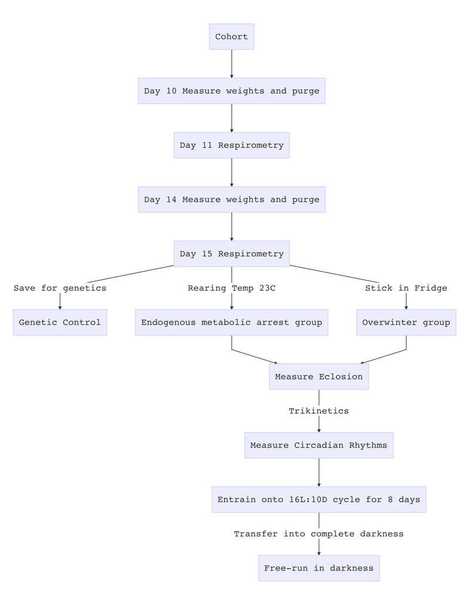

### Meta data for critical datasets

**2017-08-24_rhagoletis_data_sheet.xlsx** : master dataset where we collated different sources of data (respirometry, mass, and trikinetics annotations)

- Maggot_collections tab: Details of fruit collections, maggot collections, and when to process at different times of the workflow
- Site: broad site name
- Site_name: micro site name
- Host: host fruit
- Collect_fruit: when we collected fruit; should only be 2 dates to indicate apple and haw collection
- Collect_day: cohort day
- Collect_larvae: collection date of larvae for that cohort
- Petri_dish: petri dish number; we tried to put 100 maggots per dish
- Collector: person who collected; AN = Andrew Nguyen, PE= Pepa, TG = Tatiana, CH= Chelsea, KL= Kylie
- Petri_density: number of maggots we placed in that petri dish
- Day10_weights_date: day 10 date for when to weigh and purge a given cohort
- Day11_respirometry_date: day 11 date for when we measure co2 for a given cohort
- Day14_weights_date : day 14 date for when to weigh and purge a given cohort
- Day15_respirometry_date: day 15 date for when we measure co2 for a given cohort
- Data_collect tab: Datasheet where we entered cohort details; weights, purge times, and respirometry data; trikinetics handling details; as well as notes
- Ind_ID: initial numerical ID
- tape : tape associated with Ind_ID
- Site_name: general site name
- mass_day10: mass values at day 10 in mgs
- purge_time_1: purge time in military time (hours: minutes) at day 10
- purge1: going to convert military time to hours decimals at day 10
- collection_date: Date the fruit was collected
- day10: day 10 date
- cohort_date: initial cohort date from which we collected maggots
- cohort_day: the cohort day
- Host: host fruit ; apple or haw
- Li-cor_1: respirometry machine we used for each sample
- resp_time_1: time of when we measured sample respirometrically day 11
- resp_day11: raw respirometry values day 11
- mass_day14: mass values at day 11 in mgs
- purge_time_2: purge times in military time for the cohort at day 14
- resp_time_2: time of when we measured sample respirometrically day 15
- resp_day15: raw respirometry values day 15
- Li_cor2: additional licor id if different licor was used between days
- treatment_day15: date cohort was split into one of three treatments
- exit_fridge_date: date silmulated overwinter cohorts were removed from fridge
- notes: notes for respirometry; weights; indication of deaths and observations
- Resp_code: either 0 or 1, depending on if CO2 was produced during respirometry
- treatment: whether sample was split into the genetic control, rearing temperature (RT eclosion), or in the fridge (simulated overwintering)
- uniqueID: for apple, the ID is a combination of cohort day, first letter of tape color, and Ind_ID number; for haw, it is the same thing but uniqueIDs start with an “h” to indicate haw
- eclosion_date: eclosion day defined as an adult at least 50% emerged from pupal case.
- eclosion_days: number of days from maggot collection(cohort date) until eclosion_date
- well_id: if in RT or fridge treatment, the well id in a 96 well plate set up
- organism: fly or parasitic wasp
- Trikinetics_position: initial trikinetics position for entrainment
- Trik_monitor: initial trikinetics monitor for entrainment
- Trikinetics_entry_LD_time: entry date for entrainment
- Trikinetic_exit_date: date sample taken out from either death or moved to free-run experiment
- Trikinetics_exit_LD_time: time of exit
- notes_2: trikinetics notes for entrainment ; including deaths or escapees
- Free_run_trik_monitor: trikinetics monitor for free- run experiment
- Free_run_trik_position: trikinetics position for free - run experiment
- Free_run_entry_date: the date when a sample entered the free- run experiment
- Free_run_entry_time: the time when a sample entered the free- run experiment
- Free_run_exit_date: the date when a sample exited the free run experiment due to death
- Free_run_exit_time: the time when a sample exited the free-run experiment
- notes_3: notes for free run experiment